[figure not shown]

# Feature Selection, Model Selection and Tuning

## Project #5

## Credit Card Users Churn Prediction

# Context

The Thera bank recently saw a steep decline in the number of users of their credit card, credit cards are a good source of income for banks because of different kinds of fees charged by the banks like annual fees, balance transfer fees, and cash advance fees, late payment fees, foreign transaction fees, and others. Some fees are charged to every user irrespective of usage, while others are charged under specified circumstances.

Customers’ leaving credit cards services would lead bank to loss, so the bank wants to analyze the data of customers and identify the customers who will leave their credit card services and reason for same – so that bank could improve upon those areas

You as a Data scientist at Thera bank need to come up with a classification model that will help the bank improve its services so that customers do not renounce their credit cards

You need to identify the best possible model that will give the required performance

# Objective

1. Explore and visualize the dataset.
2. Build a classification model to predict if the customer is going to churn or not
3. Optimize the model using appropriate techniques
4. Generate a set of insights and recommendations that will help the bank

# Conclusions

- Using the provided data I was able to create a model that can accurately predict if a customer will leave the bank with 96% accuracy on data that the model has never seen before

# Recommendations

# Data Dictionary

| Labels | Description |
| --- | --- |
| CLIENTNUM | Client number. Unique identifier for the customer holding the account |

# Imports & Initial Configurations

```python
# reading and manipulating data
import pandas as pd
import numpy as np

# data visualization
%matplotlib inline
import matplotlib.pyplot as plt
import seaborn as sns

# missing value imputation
from sklearn.impute import SimpleImputer

# model building
from sklearn.linear_model import LogisticRegression
from sklearn.tree import DecisionTreeClassifier
from sklearn.ensemble import (
    AdaBoostClassifier,
    GradientBoostingClassifier,
    RandomForestClassifier,
    BaggingClassifier,
)
from xgboost import XGBClassifier

# metric scores, and split data
from sklearn import metrics
from sklearn.model_selection import train_test_split, StratifiedKFold, cross_val_score
from sklearn.metrics import (
    f1_score,
    accuracy_score,
    recall_score,
    precision_score,
    confusion_matrix,
    roc_auc_score,
    plot_confusion_matrix,
)

# data scaling and one hot encoding
from sklearn.preprocessing import StandardScaler, MinMaxScaler, OneHotEncoder


# tuning the model
from sklearn.model_selection import GridSearchCV, RandomizedSearchCV

# Under and over sampling
from imblearn.over_sampling import SMOTE
from imblearn.under_sampling import RandomUnderSampler

# pipelines
from sklearn.pipeline import Pipeline
from sklearn.compose import ColumnTransformer
from sklearn.preprocessing import FunctionTransformer

# to create pipeline and make_pipeline
from sklearn.pipeline import make_pipeline

# For Reporting
import shap

# maximum number of columns to be displayed in a dataframe
pd.set_option("display.max_columns", None)

# supress scientific notations for a dataframe
pd.set_option("display.float_format", lambda x: "%.3f" % x)

# supress warnings
import warnings

warnings.filterwarnings("ignore")

# code formatting
%load_ext nb_black
```

# Functions

```python
def treat_outliers(df, col):
    """
    treats outliers in a variable
    col: str, name of the numerical variable
    df: dataframe
    col: name of the column
    """
    Q1 = df[col].quantile(0.25)  # 25th quantile
    Q3 = df[col].quantile(0.75)  # 75th quantile
    IQR = Q3 - Q1  # Inter Quantile Range (75th perentile - 25th percentile)
    lower_whisker = Q1 - 1.5 * IQR
    upper_whisker = Q3 + 1.5 * IQR

    # all the values smaller than lower_whisker will be assigned the value of lower_whisker
    # all the values greater than upper_whisker will be assigned the value of upper_whisker
    # the assignment will be done by using the clip function of NumPy
    df[col] = np.clip(df[col], lower_whisker, upper_whisker)

    return df
```

```python
# function to create labeled barplots


def labeled_barplot(data, feature, perc=False, n=None):
    """
    Barplot with percentage at the top

    data: dataframe
    feature: dataframe column
    perc: whether to display percentages instead of count (default is False)
    n: displays the top n category levels (default is None, i.e., display all levels)
    """

    total = len(data[feature])  # length of the column
    count = data[feature].nunique()
    if n is None:
        plt.figure(figsize=(count + 1, 5))
    else:
        plt.figure(figsize=(n + 1, 5))

    plt.xticks(rotation=90, fontsize=15)
    ax = sns.countplot(
        data=data,
        x=feature,
        palette="Paired",
        order=data[feature].value_counts().index[:n].sort_values(),
    )

    for p in ax.patches:
        if perc == True:
            label = "{:.1f}%".format(
                100 * p.get_height() / total
            )  # percentage of each class of the category
        else:
            label = p.get_height()  # count of each level of the category

        x = p.get_x() + p.get_width() / 2  # width of the plot
        y = p.get_height()  # height of the plot

        ax.annotate(
            label,
            (x, y),
            ha="center",
            va="center",
            size=12,
            xytext=(0, 5),
            textcoords="offset points",
        )  # annotate the percentage

    plt.show()  # show the plot
```

```python
def confusion_matrix_sklearn(model, predictors, target):
    """
    To plot the confusion_matrix with percentages

    model: classifier
    predictors: independent variables
    target: dependent variable
    """
    y_pred = model.predict(predictors)
    cm = confusion_matrix(target, y_pred)
    labels = np.asarray(
        [
            ["{0:0.0f}".format(item) + "\n{0:.2%}".format(item / cm.flatten().sum())]
            for item in cm.flatten()
        ]
    ).reshape(2, 2)

    plt.figure(figsize=(6, 4))
    sns.heatmap(cm, annot=labels, fmt="")
    plt.ylabel("True label")
    plt.xlabel("Predicted label")
```

```python
# defining a function to compute different metrics to check performance of a classification model built using sklearn
def model_performance_classification_sklearn(model, predictors, target):
    """
    Function to compute different metrics to check classification model performance

    model: classifier
    predictors: independent variables
    target: dependent variable
    """

    # predicting using the independent variables
    pred = model.predict(predictors)

    acc = accuracy_score(target, pred)  # to compute Accuracy
    recall = recall_score(target, pred)  # to compute Recall
    precision = precision_score(target, pred)  # to compute Precision
    f1 = f1_score(target, pred)  # to compute F1-score

    # creating a dataframe of metrics
    df_perf = pd.DataFrame(
        {"Accuracy": acc, "Recall": recall, "Precision": precision, "F1": f1,},
        index=[0],
    )

    return df_perf
```

```python
# function to plot cdf for numeric values

def plot_cdf(num_cols):
    fig, axes = plt.subplots(3, 2, figsize=(20, 15))
    fig.suptitle("CDF plot of numerical variables", fontsize=20)
    counter = 0

    for i in range(3):
        sns.ecdfplot(ax=axes[i][0], x=df[num_cols[counter]])
        counter = counter + 1
        if counter != 5:
            sns.ecdfplot(ax=axes[i][1], x=df[num_cols[counter]])
            counter = counter + 1
        else:
            pass
```

```python
def visualize_outliers(num_cols):
    plt.figure(figsize=(20, 15))

    for i, variable in enumerate(num_cols):
        plt.subplot(2, 4, i)
        plt.boxplot(df[variable], whis=1.5)
        plt.tight_layout()
        plt.title(variable)

    plt.show()
```

# Load & Initial Evaluation of the Data

```python
df = pd.read_csv("BankChurners.csv")
print(f"There are {df.shape[0]} rows and {df.shape[1]} columns")
```

```
There are 10127 rows and 21 columns
```

```python
df.info()
```

```
<class 'pandas.core.frame.DataFrame'>
RangeIndex: 10127 entries, 0 to 10126
Data columns (total 21 columns):
 #   Column                    Non-Null Count  Dtype
---  ------                    --------------  -----
 0   CLIENTNUM                 10127 non-null  int64
 1   Attrition_Flag            10127 non-null  object
 2   Customer_Age              10127 non-null  int64
 3   Gender                    10127 non-null  object
 4   Dependent_count           10127 non-null  int64
 5   Education_Level           8608 non-null   object
 6   Marital_Status            9378 non-null   object
 7   Income_Category           10127 non-null  object
 8   Card_Category             10127 non-null  object
 9   Months_on_book            10127 non-null  int64
 10  Total_Relationship_Count  10127 non-null  int64
 11  Months_Inactive_12_mon    10127 non-null  int64
 12  Contacts_Count_12_mon     10127 non-null  int64
 13  Credit_Limit              10127 non-null  float64
 14  Total_Revolving_Bal       10127 non-null  int64
 15  Avg_Open_To_Buy           10127 non-null  float64
 16  Total_Amt_Chng_Q4_Q1      10127 non-null  float64
 17  Total_Trans_Amt           10127 non-null  int64
 18  Total_Trans_Ct            10127 non-null  int64
 19  Total_Ct_Chng_Q4_Q1       10127 non-null  float64
 20  Avg_Utilization_Ratio     10127 non-null  float64
dtypes: float64(5), int64(10), object(6)
memory usage: 1.6+ MB
```

## NOTE:

Several fields are objects that will need to be converted to numerical values

```python
# Remove the CustomerID column as it has no value to the model
df.drop(df.columns[[0]], axis=1, inplace=True)
```

```python
df["Attrition_Flag"] = df["Attrition_Flag"].replace(["Existing Customer"], 1)
df["Attrition_Flag"] = df["Attrition_Flag"].replace(["Attrited Customer"], 0)
df["Marital_Status"] = df["Marital_Status"].fillna("Unknown")
df["Education_Level"] = df["Education_Level"].fillna("Unknown")
```

```python
df.head(10)
```

|  | Attrition_Flag | Customer_Age | Gender | Dependent_count | Education_Level | Marital_Status | Income_Category | Card_Category | Months_on_book | Total_Relationship_Count | Months_Inactive_12_mon | Contacts_Count_12_mon | Credit_Limit | Total_Revolving_Bal | Avg_Open_To_Buy | Total_Amt_Chng_Q4_Q1 | Total_Trans_Amt | Total_Trans_Ct | Total_Ct_Chng_Q4_Q1 | Avg_Utilization_Ratio |
| --- | --- | --- | --- | --- | --- | --- | --- | --- | --- | --- | --- | --- | --- | --- | --- | --- | --- | --- | --- | --- |
| 0 | 1 | 45 | M | 3 | High School | Married | $60K - $80K | Blue | 39 | 5 | 1 | 3 | 12691.000 | 777 | 11914.000 | 1.335 | 1144 | 42 | 1.625 | 0.061 |
| 1 | 1 | 49 | F | 5 | Graduate | Single | Less than $40K | Blue | 44 | 6 | 1 | 2 | 8256.000 | 864 | 7392.000 | 1.541 | 1291 | 33 | 3.714 | 0.105 |
| 2 | 1 | 51 | M | 3 | Graduate | Married | $80K - $120K | Blue | 36 | 4 | 1 | 0 | 3418.000 | 0 | 3418.000 | 2.594 | 1887 | 20 | 2.333 | 0.000 |
| 3 | 1 | 40 | F | 4 | High School | Unknown | Less than $40K | Blue | 34 | 3 | 4 | 1 | 3313.000 | 2517 | 796.000 | 1.405 | 1171 | 20 | 2.333 | 0.760 |
| 4 | 1 | 40 | M | 3 | Uneducated | Married | $60K - $80K | Blue | 21 | 5 | 1 | 0 | 4716.000 | 0 | 4716.000 | 2.175 | 816 | 28 | 2.500 | 0.000 |
| 5 | 1 | 44 | M | 2 | Graduate | Married | $40K - $60K | Blue | 36 | 3 | 1 | 2 | 4010.000 | 1247 | 2763.000 | 1.376 | 1088 | 24 | 0.846 | 0.311 |
| 6 | 1 | 51 | M | 4 | Unknown | Married | $120K + | Gold | 46 | 6 | 1 | 3 | 34516.000 | 2264 | 32252.000 | 1.975 | 1330 | 31 | 0.722 | 0.066 |
| 7 | 1 | 32 | M | 0 | High School | Unknown | $60K - $80K | Silver | 27 | 2 | 2 | 2 | 29081.000 | 1396 | 27685.000 | 2.204 | 1538 | 36 | 0.714 | 0.048 |
| 8 | 1 | 37 | M | 3 | Uneducated | Single | $60K - $80K | Blue | 36 | 5 | 2 | 0 | 22352.000 | 2517 | 19835.000 | 3.355 | 1350 | 24 | 1.182 | 0.113 |
| 9 | 1 | 48 | M | 2 | Graduate | Single | $80K - $120K | Blue | 36 | 6 | 3 | 3 | 11656.000 | 1677 | 9979.000 | 1.524 | 1441 | 32 | 0.882 | 0.144 |

```python
# Convert object type columns to be categories

for feature in df.columns:  # Loop through all columns in the dataframe
    if df[feature].dtype == "object":  # Only apply for columns with categorical strings
        df[feature] = pd.Categorical(df[feature])
```

```python
df.head(10)
```

|  | Attrition_Flag | Customer_Age | Gender | Dependent_count | Education_Level | Marital_Status | Income_Category | Card_Category | Months_on_book | Total_Relationship_Count | Months_Inactive_12_mon | Contacts_Count_12_mon | Credit_Limit | Total_Revolving_Bal | Avg_Open_To_Buy | Total_Amt_Chng_Q4_Q1 | Total_Trans_Amt | Total_Trans_Ct | Total_Ct_Chng_Q4_Q1 | Avg_Utilization_Ratio |
| --- | --- | --- | --- | --- | --- | --- | --- | --- | --- | --- | --- | --- | --- | --- | --- | --- | --- | --- | --- | --- |
| 0 | 1 | 45 | M | 3 | High School | Married | $60K - $80K | Blue | 39 | 5 | 1 | 3 | 12691.000 | 777 | 11914.000 | 1.335 | 1144 | 42 | 1.625 | 0.061 |
| 1 | 1 | 49 | F | 5 | Graduate | Single | Less than $40K | Blue | 44 | 6 | 1 | 2 | 8256.000 | 864 | 7392.000 | 1.541 | 1291 | 33 | 3.714 | 0.105 |
| 2 | 1 | 51 | M | 3 | Graduate | Married | $80K - $120K | Blue | 36 | 4 | 1 | 0 | 3418.000 | 0 | 3418.000 | 2.594 | 1887 | 20 | 2.333 | 0.000 |
| 3 | 1 | 40 | F | 4 | High School | Unknown | Less than $40K | Blue | 34 | 3 | 4 | 1 | 3313.000 | 2517 | 796.000 | 1.405 | 1171 | 20 | 2.333 | 0.760 |
| 4 | 1 | 40 | M | 3 | Uneducated | Married | $60K - $80K | Blue | 21 | 5 | 1 | 0 | 4716.000 | 0 | 4716.000 | 2.175 | 816 | 28 | 2.500 | 0.000 |
| 5 | 1 | 44 | M | 2 | Graduate | Married | $40K - $60K | Blue | 36 | 3 | 1 | 2 | 4010.000 | 1247 | 2763.000 | 1.376 | 1088 | 24 | 0.846 | 0.311 |
| 6 | 1 | 51 | M | 4 | Unknown | Married | $120K + | Gold | 46 | 6 | 1 | 3 | 34516.000 | 2264 | 32252.000 | 1.975 | 1330 | 31 | 0.722 | 0.066 |
| 7 | 1 | 32 | M | 0 | High School | Unknown | $60K - $80K | Silver | 27 | 2 | 2 | 2 | 29081.000 | 1396 | 27685.000 | 2.204 | 1538 | 36 | 0.714 | 0.048 |
| 8 | 1 | 37 | M | 3 | Uneducated | Single | $60K - $80K | Blue | 36 | 5 | 2 | 0 | 22352.000 | 2517 | 19835.000 | 3.355 | 1350 | 24 | 1.182 | 0.113 |
| 9 | 1 | 48 | M | 2 | Graduate | Single | $80K - $120K | Blue | 36 | 6 | 3 | 3 | 11656.000 | 1677 | 9979.000 | 1.524 | 1441 | 32 | 0.882 | 0.144 |

```python
# Get the value_counts for all the colums.  This is useful to understand if there are data entry or acquisition errors
# that need to be fixed before attempting to build the models

for feature in df.columns:  # Loop through all the columns in the dataframe
    print(f"Unique values in {feature} are:")
    print(f"{df[feature].value_counts()}")
    print("*" * 50)
```

```
Unique values in Attrition_Flag are:
1    8500
0    1627
Name: Attrition_Flag, dtype: int64
Unique values in Customer_Age are:
44    500
49    495
46    490
45    486
47    479
43    473
48    472
50    452
42    426
51    398
53    387
41    379
52    376
40    361
39    333
54    307
38    303
55    279
56    262
37    260
57    223
36    221
35    184
58    157
59    157
34    146
33    127
60    127
32    106
65    101
61     93
62     93
31     91
26     78
30     70
```

[output cut: 213 more lines]

```
1.074      1
Name: Total_Ct_Chng_Q4_Q1, Length: 830, dtype: int64
Unique values in Avg_Utilization_Ratio are:
0.000    2470
0.073      44
0.057      33
0.048      32
0.060      30
         ...
0.335       1
0.985       1
0.949       1
0.818       1
0.972       1
Name: Avg_Utilization_Ratio, Length: 964, dtype: int64
```

```python
# The value_counts data has pinpointed several issues that need to be resolved before going forward. This section
# will clean up the data

## Education_Level
df['Education_Level'] = df['Education_Level'].replace(['High School'], 'High_School')
df['Education_Level'] = df['Education_Level'].replace(['College'], 'Student')
df['Education_Level'] = df['Education_Level'].replace([np.nan], 'Unknown')

## Income_Category
df['Income_Category'] = df['Income_Category'].replace(['abc'], 'Unknown')
```

```python
# Repeat the value_counts to verify that all the issue have been resolved

for feature in df.columns:  # Loop through all the columns in the dataframe
    print(f"Unique values in {feature} are:")
    print(f"{df[feature].value_counts()}")
    print("*" * 50)
```

```
Unique values in Attrition_Flag are:
1    8500
0    1627
Name: Attrition_Flag, dtype: int64
Unique values in Customer_Age are:
44    500
49    495
46    490
45    486
47    479
43    473
48    472
50    452
42    426
51    398
53    387
41    379
52    376
40    361
39    333
54    307
38    303
55    279
56    262
37    260
57    223
36    221
35    184
58    157
59    157
34    146
33    127
60    127
32    106
65    101
61     93
62     93
31     91
26     78
30     70
```

[output cut: 213 more lines]

```
1.074      1
Name: Total_Ct_Chng_Q4_Q1, Length: 830, dtype: int64
Unique values in Avg_Utilization_Ratio are:
0.000    2470
0.073      44
0.057      33
0.048      32
0.060      30
         ...
0.335       1
0.985       1
0.949       1
0.818       1
0.972       1
Name: Avg_Utilization_Ratio, Length: 964, dtype: int64
```

```python
# Statistical Summary of the data
df.describe().T
```

|  | count | mean | std | min | 25% | 50% | 75% | max |
| --- | --- | --- | --- | --- | --- | --- | --- | --- |
| Attrition_Flag | 10127.000 | 0.839 | 0.367 | 0.000 | 1.000 | 1.000 | 1.000 | 1.000 |
| Customer_Age | 10127.000 | 46.326 | 8.017 | 26.000 | 41.000 | 46.000 | 52.000 | 73.000 |
| Dependent_count | 10127.000 | 2.346 | 1.299 | 0.000 | 1.000 | 2.000 | 3.000 | 5.000 |
| Months_on_book | 10127.000 | 35.928 | 7.986 | 13.000 | 31.000 | 36.000 | 40.000 | 56.000 |
| Total_Relationship_Count | 10127.000 | 3.813 | 1.554 | 1.000 | 3.000 | 4.000 | 5.000 | 6.000 |
| Months_Inactive_12_mon | 10127.000 | 2.341 | 1.011 | 0.000 | 2.000 | 2.000 | 3.000 | 6.000 |
| Contacts_Count_12_mon | 10127.000 | 2.455 | 1.106 | 0.000 | 2.000 | 2.000 | 3.000 | 6.000 |
| Credit_Limit | 10127.000 | 8631.954 | 9088.777 | 1438.300 | 2555.000 | 4549.000 | 11067.500 | 34516.000 |
| Total_Revolving_Bal | 10127.000 | 1162.814 | 814.987 | 0.000 | 359.000 | 1276.000 | 1784.000 | 2517.000 |
| Avg_Open_To_Buy | 10127.000 | 7469.140 | 9090.685 | 3.000 | 1324.500 | 3474.000 | 9859.000 | 34516.000 |
| Total_Amt_Chng_Q4_Q1 | 10127.000 | 0.760 | 0.219 | 0.000 | 0.631 | 0.736 | 0.859 | 3.397 |
| Total_Trans_Amt | 10127.000 | 4404.086 | 3397.129 | 510.000 | 2155.500 | 3899.000 | 4741.000 | 18484.000 |
| Total_Trans_Ct | 10127.000 | 64.859 | 23.473 | 10.000 | 45.000 | 67.000 | 81.000 | 139.000 |
| Total_Ct_Chng_Q4_Q1 | 10127.000 | 0.712 | 0.238 | 0.000 | 0.582 | 0.702 | 0.818 | 3.714 |
| Avg_Utilization_Ratio | 10127.000 | 0.275 | 0.276 | 0.000 | 0.023 | 0.176 | 0.503 | 0.999 |

### Notes:

- The average customer age is 46. The yougest is 26, the oldest is 73
- The average time the customers have been with the bank is just under 3 years. The minimum is 13 months, the maximum is 4.6 years
- the average credit limit is $8,631. The lowest credit limit is $1,438 and the highest is $34,516
- The average balance is $1,162. The lowest balance is $0 and the highest is $2,517
- The average number of transaction is 64, with the min of 10 and the max of 139

```python
# precentage of missing values in columns
round(df.isna().sum() / df.isna().count() * 100, 2)
```

```
Attrition_Flag             0.000
Customer_Age               0.000
Gender                     0.000
Dependent_count            0.000
Education_Level            0.000
Marital_Status             0.000
Income_Category            0.000
Card_Category              0.000
Months_on_book             0.000
Total_Relationship_Count   0.000
Months_Inactive_12_mon     0.000
Contacts_Count_12_mon      0.000
Credit_Limit               0.000
Total_Revolving_Bal        0.000
Avg_Open_To_Buy            0.000
Total_Amt_Chng_Q4_Q1       0.000
Total_Trans_Amt            0.000
Total_Trans_Ct             0.000
Total_Ct_Chng_Q4_Q1        0.000
Avg_Utilization_Ratio      0.000
dtype: float64
```

## Note:

```python
# Check for and themn remove duplicate data
df.duplicated().sum()
```

```
0
```

## No Duplicates are found so the next two lines are commented out

```python
# df.drop_duplicates(inplace=True)
# df.reset_index(drop=True, inplace=True)
```

```python
df.info()
```

```
<class 'pandas.core.frame.DataFrame'>
RangeIndex: 10127 entries, 0 to 10126
Data columns (total 20 columns):
 #   Column                    Non-Null Count  Dtype
---  ------                    --------------  -----
 0   Attrition_Flag            10127 non-null  int64
 1   Customer_Age              10127 non-null  int64
 2   Gender                    10127 non-null  category
 3   Dependent_count           10127 non-null  int64
 4   Education_Level           10127 non-null  category
 5   Marital_Status            10127 non-null  category
 6   Income_Category           10127 non-null  category
 7   Card_Category             10127 non-null  category
 8   Months_on_book            10127 non-null  int64
 9   Total_Relationship_Count  10127 non-null  int64
 10  Months_Inactive_12_mon    10127 non-null  int64
 11  Contacts_Count_12_mon     10127 non-null  int64
 12  Credit_Limit              10127 non-null  float64
 13  Total_Revolving_Bal       10127 non-null  int64
 14  Avg_Open_To_Buy           10127 non-null  float64
 15  Total_Amt_Chng_Q4_Q1      10127 non-null  float64
 16  Total_Trans_Amt           10127 non-null  int64
 17  Total_Trans_Ct            10127 non-null  int64
 18  Total_Ct_Chng_Q4_Q1       10127 non-null  float64
 19  Avg_Utilization_Ratio     10127 non-null  float64
dtypes: category(5), float64(5), int64(10)
memory usage: 1.2 MB
```

```python
categorical_cols = [
    "Gender",
    "Education_Level",
    "Marital_Status",
    "Income_Category",
    "Card_Category",
]

numerical_cols = [
    "Customer_Age",
    "Dependent_count",
    "Months_on_book",
    "Total_Relationship_Count",
    "Months_Inactive_12_mon",
    "Contacts_Count_12_mon",
    "Credit_Limit",
    "Total_Revolving_Bal",
    "Avg_Open_To_Buy",
    "Total_Amt_Chng_Q4_Q1",
    "Total_Trans_Amt",
    "Total_Trans_Ct",
    "Total_Ct_Chng_Q4_Q1",
    "Avg_Utilization_Ratio",
]
```

## Note:

After cleaning up the data we are left with 10,127 rows

# EDA

## Univariate Analysis

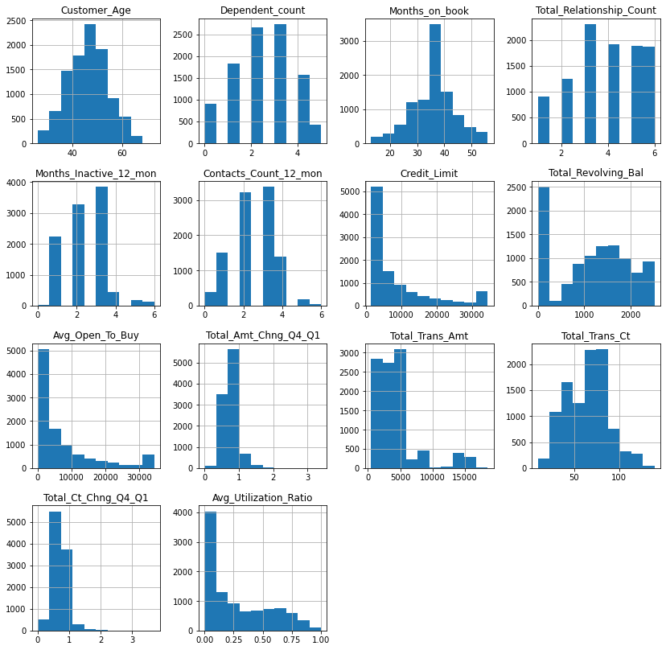

```python
df[numerical_cols].hist(figsize=(14, 14))
plt.show()
```

### Data with Outliers

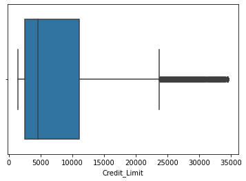

```python
sns.boxplot(data=df, x="Credit_Limit")
```

```python
df = treat_outliers(df, "Credit_Limit")
```

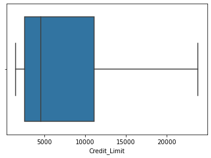

```python
# View of the data range after treating outliers
sns.boxplot(data=df, x="Credit_Limit")
```

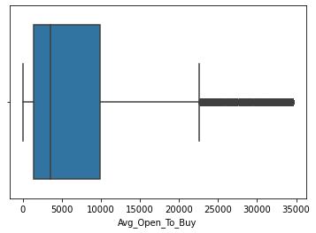

```python
sns.boxplot(data=df, x="Avg_Open_To_Buy")
```

```python
df = treat_outliers(df, "Avg_Open_To_Buy")
```

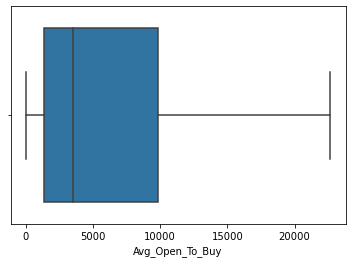

```python
# View of the data range after treating outliers
sns.boxplot(data=df, x="Avg_Open_To_Buy")
```

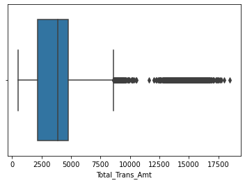

```python
sns.boxplot(data=df, x="Total_Trans_Amt")
```

```python
df = treat_outliers(df, "Total_Trans_Amt")
```

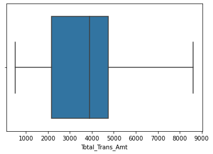

```python
# View of the data range after treating outliers
sns.boxplot(data=df, x="Total_Trans_Amt")
```

### Notes:

- The impact of treating the outliers is currently unknown. GreadientBoost was determined to be the best performing model after treating the outliers, but this model is supposed to be unaffected by outliers. If I have time I will run the notebook without treating outliers to see if the same result is achieved.

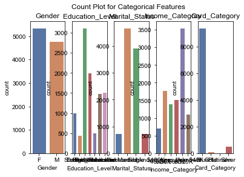

```python
fig, axes = plt.subplots(1, 5)
fig.suptitle("Count Plot for Categorical Features")
sns.set(rc={"figure.figsize": (20, 5)})

sns.countplot(ax=axes[0], x=categorical_cols[0], data=df)
axes[0].set_title(categorical_cols[0])

sns.countplot(ax=axes[1], x=categorical_cols[1], data=df)
axes[1].set_title(categorical_cols[1])

sns.countplot(ax=axes[2], x=categorical_cols[2], data=df)
axes[2].set_title(categorical_cols[2])

sns.countplot(ax=axes[3], x=categorical_cols[3], data=df)
axes[3].set_title(categorical_cols[3])

sns.countplot(ax=axes[4], x=categorical_cols[4], data=df)
axes[4].set_title(categorical_cols[4])


plt.show()
```

### Notes:

- More female customers
- More married custoers (but only by a small margin)
- Most custoers have the "Blue" card

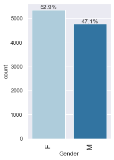

```python
labeled_barplot(df, "Gender", perc=True)
```

### Notes:

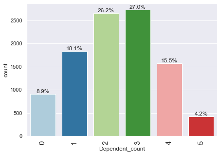

```python
labeled_barplot(df, "Dependent_count", perc=True)
```

### Notes:

- A majority of the customers have 2 or 3 kids
- Only 8.9% have 0 kids
- 4.2% have 5 kids

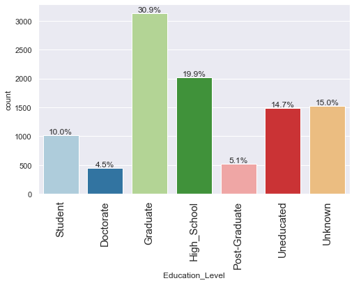

```python
labeled_barplot(df, "Education_Level", perc=True)
```

### Notes:

- 40.5% of cusotmers have graduated college
- 10% are currently students
- 14.7% are considered uneducated

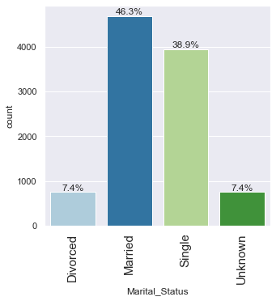

```python
labeled_barplot(df, "Marital_Status", perc=True)
```

### Notes:

- 46.3% are married
- 46.3% are either single or divorced

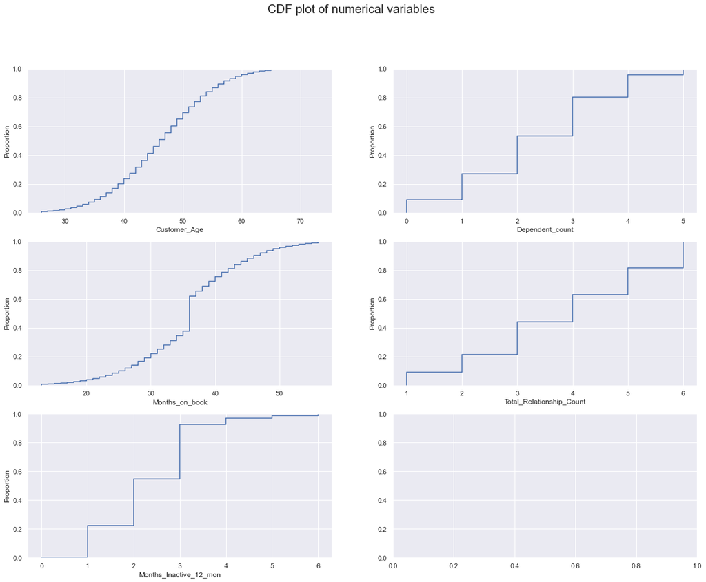

```python
plot_cdf(numerical_cols)
```

## Bi-variate Data Analysis

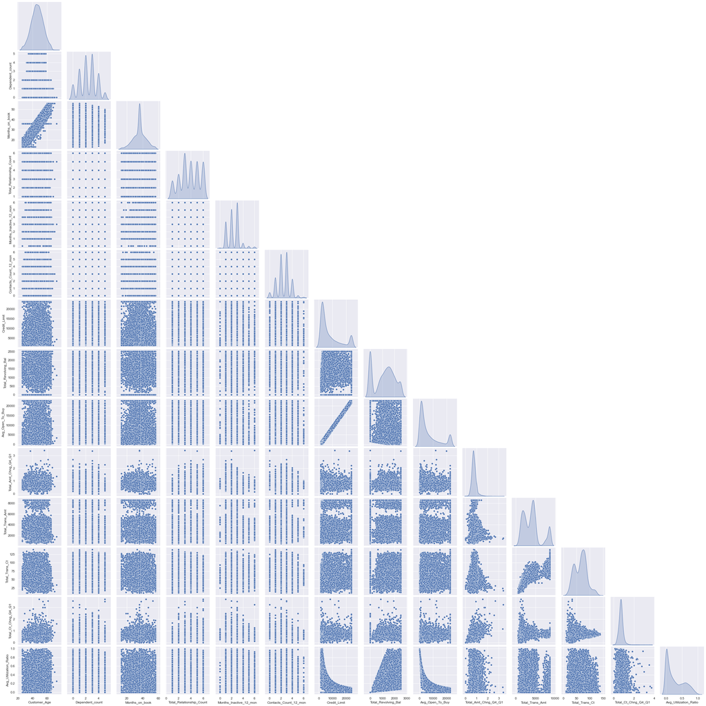

```python
sns.pairplot(df[numerical_cols], diag_kind="kde", corner=True)
```

### Notes:

- To be hones I am not entirely sure what observations can be derived from this chart

```
<function matplotlib.pyplot.show(close=None, block=None)>
```

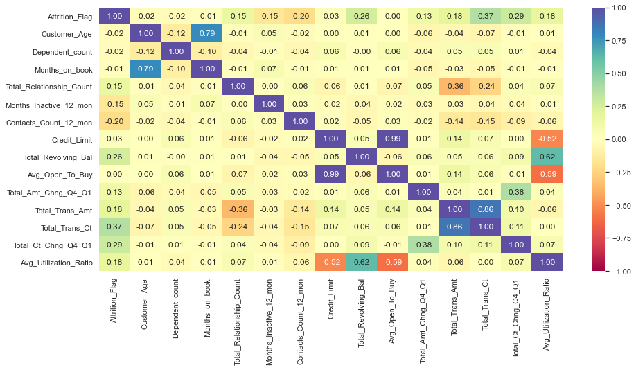

```python
plt.figure(figsize=(15, 7))
sns.heatmap(df.corr(), annot=True, vmin=-1, vmax=1, fmt=".2f", cmap="Spectral")
plt.show
```

### Notes:

- Customers age is highly correlated to how long they have been a customer
- The top correlation to the Attrition_Flag is Total_Trans_Ct, followed by Total_Ct_Chng_Q4_Q1 and then Total_Revolving_Bal

```python
# Mean of numerical variables grouped by attrition
df.groupby(["Attrition_Flag"])[numerical_cols].mean()
```

| Attrition_Flag | Customer_Age | Dependent_count | Months_on_book | Total_Relationship_Count | Months_Inactive_12_mon | Contacts_Count_12_mon | Credit_Limit | Total_Revolving_Bal | Avg_Open_To_Buy | Total_Amt_Chng_Q4_Q1 | Total_Trans_Amt | Total_Trans_Ct | Total_Ct_Chng_Q4_Q1 | Avg_Utilization_Ratio |
| --- | --- | --- | --- | --- | --- | --- | --- | --- | --- | --- | --- | --- | --- | --- |
| 0 | 46.659 | 2.403 | 36.178 | 3.280 | 2.693 | 2.972 | 7366.520 | 672.823 | 6643.325 | 0.694 | 3060.262 | 44.934 | 0.554 | 0.162 |
| 1 | 46.262 | 2.335 | 35.881 | 3.915 | 2.274 | 2.356 | 7981.037 | 1256.604 | 6735.482 | 0.773 | 4118.340 | 68.673 | 0.742 | 0.296 |

### Notes:

- Customers who leave have -- lower Total_Revolving_Bal -- lower Total_Trans_Amt -- 1/3 less Total_Trans_Ct

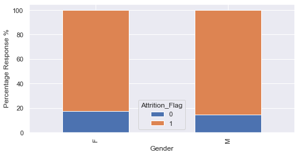

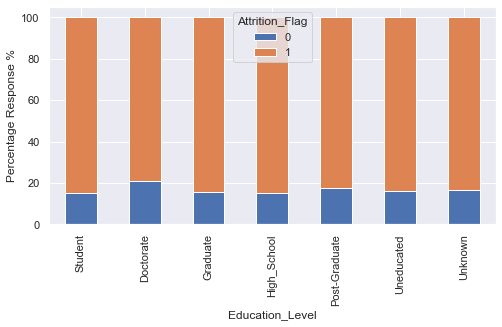

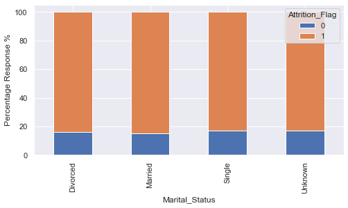

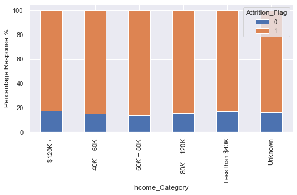

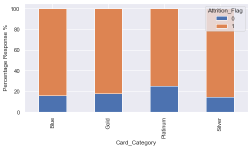

```python
for i in categorical_cols:
    if i != "Attrition_Flag":
        (pd.crosstab(df[i], df["Attrition_Flag"], normalize="index") * 100).plot(
            kind="bar", figsize=(8, 4), stacked=True
        )
        plt.ylabel("Percentage Response %")
```

### Note:

# Data Cleanup

```python
# we need to convert all the columns that have text data and convery it some how to be numerical.
# I will use pd.get_dummies to do this

oneHotCols = [
    "Gender",
    "Education_Level",
    "Marital_Status",
    "Income_Category",
    "Card_Category",
]
df = pd.get_dummies(df, columns=oneHotCols, drop_first=True)
```

```python
df.describe(include="all").T
```

|  | count | mean | std | min | 25% | 50% | 75% | max |
| --- | --- | --- | --- | --- | --- | --- | --- | --- |
| Attrition_Flag | 10127.000 | 0.839 | 0.367 | 0.000 | 1.000 | 1.000 | 1.000 | 1.000 |
| Customer_Age | 10127.000 | 46.326 | 8.017 | 26.000 | 41.000 | 46.000 | 52.000 | 73.000 |
| Dependent_count | 10127.000 | 2.346 | 1.299 | 0.000 | 1.000 | 2.000 | 3.000 | 5.000 |
| Months_on_book | 10127.000 | 35.928 | 7.986 | 13.000 | 31.000 | 36.000 | 40.000 | 56.000 |
| Total_Relationship_Count | 10127.000 | 3.813 | 1.554 | 1.000 | 3.000 | 4.000 | 5.000 | 6.000 |
| Months_Inactive_12_mon | 10127.000 | 2.341 | 1.011 | 0.000 | 2.000 | 2.000 | 3.000 | 6.000 |
| Contacts_Count_12_mon | 10127.000 | 2.455 | 1.106 | 0.000 | 2.000 | 2.000 | 3.000 | 6.000 |
| Credit_Limit | 10127.000 | 7882.309 | 7217.091 | 1438.300 | 2555.000 | 4549.000 | 11067.500 | 23836.250 |
| Total_Revolving_Bal | 10127.000 | 1162.814 | 814.987 | 0.000 | 359.000 | 1276.000 | 1784.000 | 2517.000 |
| Avg_Open_To_Buy | 10127.000 | 6720.676 | 7223.542 | 3.000 | 1324.500 | 3474.000 | 9859.000 | 22660.750 |
| Total_Amt_Chng_Q4_Q1 | 10127.000 | 0.760 | 0.219 | 0.000 | 0.631 | 0.736 | 0.859 | 3.397 |
| Total_Trans_Amt | 10127.000 | 3948.350 | 2161.970 | 510.000 | 2155.500 | 3899.000 | 4741.000 | 8619.250 |
| Total_Trans_Ct | 10127.000 | 64.859 | 23.473 | 10.000 | 45.000 | 67.000 | 81.000 | 139.000 |
| Total_Ct_Chng_Q4_Q1 | 10127.000 | 0.712 | 0.238 | 0.000 | 0.582 | 0.702 | 0.818 | 3.714 |
| Avg_Utilization_Ratio | 10127.000 | 0.275 | 0.276 | 0.000 | 0.023 | 0.176 | 0.503 | 0.999 |
| Gender_M | 10127.000 | 0.471 | 0.499 | 0.000 | 0.000 | 0.000 | 1.000 | 1.000 |
| Education_Level_Doctorate | 10127.000 | 0.045 | 0.206 | 0.000 | 0.000 | 0.000 | 0.000 | 1.000 |
| Education_Level_Graduate | 10127.000 | 0.309 | 0.462 | 0.000 | 0.000 | 0.000 | 1.000 | 1.000 |
| Education_Level_High_School | 10127.000 | 0.199 | 0.399 | 0.000 | 0.000 | 0.000 | 0.000 | 1.000 |
| Education_Level_Post-Graduate | 10127.000 | 0.051 | 0.220 | 0.000 | 0.000 | 0.000 | 0.000 | 1.000 |
| Education_Level_Uneducated | 10127.000 | 0.147 | 0.354 | 0.000 | 0.000 | 0.000 | 0.000 | 1.000 |
| Education_Level_Unknown | 10127.000 | 0.150 | 0.357 | 0.000 | 0.000 | 0.000 | 0.000 | 1.000 |
| Marital_Status_Married | 10127.000 | 0.463 | 0.499 | 0.000 | 0.000 | 0.000 | 1.000 | 1.000 |
| Marital_Status_Single | 10127.000 | 0.389 | 0.488 | 0.000 | 0.000 | 0.000 | 1.000 | 1.000 |
| Marital_Status_Unknown | 10127.000 | 0.074 | 0.262 | 0.000 | 0.000 | 0.000 | 0.000 | 1.000 |
| Income_Category_$40K - $60K | 10127.000 | 0.177 | 0.381 | 0.000 | 0.000 | 0.000 | 0.000 | 1.000 |
| Income_Category_$60K - $80K | 10127.000 | 0.138 | 0.345 | 0.000 | 0.000 | 0.000 | 0.000 | 1.000 |
| Income_Category_$80K - $120K | 10127.000 | 0.152 | 0.359 | 0.000 | 0.000 | 0.000 | 0.000 | 1.000 |
| Income_Category_Less than $40K | 10127.000 | 0.352 | 0.478 | 0.000 | 0.000 | 0.000 | 1.000 | 1.000 |
| Income_Category_Unknown | 10127.000 | 0.110 | 0.313 | 0.000 | 0.000 | 0.000 | 0.000 | 1.000 |
| Card_Category_Gold | 10127.000 | 0.011 | 0.106 | 0.000 | 0.000 | 0.000 | 0.000 | 1.000 |
| Card_Category_Platinum | 10127.000 | 0.002 | 0.044 | 0.000 | 0.000 | 0.000 | 0.000 | 1.000 |
| Card_Category_Silver | 10127.000 | 0.055 | 0.228 | 0.000 | 0.000 | 0.000 | 0.000 | 1.000 |

```python
# this is how the dataframe looks after all the fixing up
print(f"There are {df.shape[0]} rows and {df.shape[1]} columns")
```

```
There are 10127 rows and 33 columns
```

```python
df1 = df.copy()
```

# Split the data into train, validation, & test sets

```python
# Build a new dataframe, Drop the ProdTaken from the X dataframe and drop everyhing but ProdTaken from the y dataframe

X = df1.drop("Attrition_Flag", axis=1)
y = df1["Attrition_Flag"]

X = pd.get_dummies(X, drop_first=True)
```

```python
# Split the data into train and test, with test being 30% of the data, train being 70%
# I will use stratify=y to attempt to keep the ration of the data correct

# first we split data into 2 parts, say temporary and test
X_temp, X_test, y_temp, y_test = train_test_split(
    X, y, test_size=0.2, random_state=1, stratify=y
)

# then we split the temporary set into train and validation
X_train, X_val, y_train, y_val = train_test_split(
    X_temp, y_temp, test_size=0.2, random_state=1, stratify=y_temp
)

print(X_train.shape, X_val.shape, X_test.shape)
```

```
(6480, 32) (1621, 32) (2026, 32)
```

```python
X_train.isnull()
```

[output not shown]

6480 rows × 32 columns

## Note:

There are too many rows in the data to see if there are any null values in the data so we will attempt to find any missing data by calculating the perfentage that isna

```python
# precentage of missing values in columns
round(X_train.isna().sum() / X_train.isna().count() * 100, 2)
```

```
Customer_Age                     0.000
Dependent_count                  0.000
Months_on_book                   0.000
Total_Relationship_Count         0.000
Months_Inactive_12_mon           0.000
Contacts_Count_12_mon            0.000
Credit_Limit                     0.000
Total_Revolving_Bal              0.000
Avg_Open_To_Buy                  0.000
Total_Amt_Chng_Q4_Q1             0.000
Total_Trans_Amt                  0.000
Total_Trans_Ct                   0.000
Total_Ct_Chng_Q4_Q1              0.000
Avg_Utilization_Ratio            0.000
Gender_M                         0.000
Education_Level_Doctorate        0.000
Education_Level_Graduate         0.000
Education_Level_High_School      0.000
Education_Level_Post-Graduate    0.000
Education_Level_Uneducated       0.000
Education_Level_Unknown          0.000
Marital_Status_Married           0.000
Marital_Status_Single            0.000
Marital_Status_Unknown           0.000
Income_Category_$40K - $60K      0.000
Income_Category_$60K - $80K      0.000
Income_Category_$80K - $120K     0.000
Income_Category_Less than $40K   0.000
Income_Category_Unknown          0.000
Card_Category_Gold               0.000
Card_Category_Platinum           0.000
Card_Category_Silver             0.000
dtype: float64
```

## Verify Class Balance

```python
print("Target value ratio in y")
print(y.value_counts(1))
print("*" * 80)
print("Target value ratio in y_train")
print(y_train.value_counts(1))
print("*" * 80)
print("Target value ratio in y_val")
print(y_val.value_counts(1))
print("*" * 80)
print("Target value ratio in y_test")
print(y_test.value_counts(1))
print("*" * 80)
```

```
Target value ratio in y
1   0.839
0   0.161
Name: Attrition_Flag, dtype: float64
Target value ratio in y_train
1   0.839
0   0.161
Name: Attrition_Flag, dtype: float64
Target value ratio in y_val
1   0.839
0   0.161
Name: Attrition_Flag, dtype: float64
Target value ratio in y_test
1   0.840
0   0.160
Name: Attrition_Flag, dtype: float64
```

## Model Evaluations Criteria

# Models

## Base models

```python
scorecard = []
```

```python
models = []
models.append(
    (
        "Logistic Regression",
        BaggingClassifier(
            base_estimator=LogisticRegression(
                solver="liblinear", random_state=1, max_iter=1000
            ),
            random_state=1,
        ),
    )
)
models.append(("Decision Tree", DecisionTreeClassifier(random_state=1, max_depth=4)))
models.append(("Bagging", BaggingClassifier(random_state=1)))
models.append(("AdaBoost", AdaBoostClassifier(random_state=1)))
models.append(("GradientBoost", GradientBoostingClassifier(random_state=1)))
models.append(("RandomForest", RandomForestClassifier(random_state=1)))
models.append(("XGBoost", XGBClassifier(random_state=1, eval_metric="logloss")))

base_results = []
names = []

# mean cross validaton score
print(f"\nCross-Validation Performance:\n")

for name, model in models:
    scoring = "recall"
    kfold = StratifiedKFold(n_splits=5, shuffle=True, random_state=1)
    cv_result = cross_val_score(
        estimator=model, X=X_train, y=y_train, scoring=scoring, cv=kfold
    )

    base_results.append(cv_result)
    names.append(name)
    print(f"{name}: {cv_result.mean() * 100}")

print(f"\nTraining Performance:\n")

for name, model in models:
    model.fit(X_train, y_train)
    # scores = recall_score(y_train, model.predict(X_train)) * 100
    scores = model_performance_classification_sklearn(model, X_train, y_train)
    val_scores = model_performance_classification_sklearn(model, X_val, y_val)

    print(f"{name}:\n")
    print(f"Training Performace:")
    print(f"{scores}\n")

    print(f"Validation Performance:")
    print(f"{val_scores}\n")

    scorecard.append((name, scores, val_scores))
```

```
Cross-Validation Performance:

Logistic Regression: 96.65388752096975
Decision Tree: 97.55484265923482
Bagging: 97.31571987120515
AdaBoost: 98.12457722279345
GradientBoost: 98.76812868661725
RandomForest: 98.65781765788192
XGBoost: 98.71296471670546

Training Performance:

Logistic Regression:

Training Performace:
   Accuracy  Recall  Precision    F1
0     0.898   0.967      0.916 0.941

Validation Performance:
   Accuracy  Recall  Precision    F1
0     0.901   0.973      0.915 0.943

Decision Tree:

Training Performace:
   Accuracy  Recall  Precision    F1
0     0.929   0.985      0.935 0.959

Validation Performance:
   Accuracy  Recall  Precision    F1
0     0.918   0.985      0.923 0.953

Bagging:

Training Performace:
   Accuracy  Recall  Precision    F1
0     0.996   0.997      0.999 0.998

Validation Performance:
   Accuracy  Recall  Precision    F1
```

[output cut: 26 more lines]

```
0     1.000   1.000      1.000 1.000

Validation Performance:
   Accuracy  Recall  Precision    F1
0     0.950   0.989      0.953 0.971

XGBoost:

Training Performace:
   Accuracy  Recall  Precision    F1
0     1.000   1.000      1.000 1.000

Validation Performance:
   Accuracy  Recall  Precision    F1
0     0.970   0.986      0.979 0.982
```

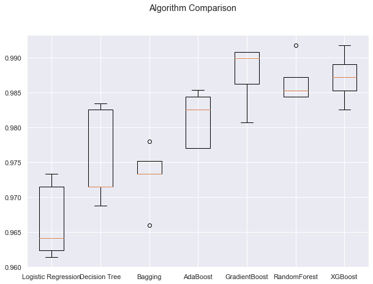

```python
fig = plt.figure(figsize=(10, 7))

fig.suptitle("Algorithm Comparison")
ax = fig.add_subplot(111)

plt.boxplot(base_results)
ax.set_xticklabels(names)

plt.show()
```

## Oversampled data

```python
print(f"\nTraining\n")
print(f"Before Oversampling, counts of label 'Yes': {sum(y_train == 1)}")
print(f"Before Oversampling, countd of label 'No': {sum(y_train == 0)}\n")

print(f"\nValidation\n")
print(f"Before Oversampling, counts of label 'Yes': {sum(y_val == 1)}")
print(f"Before Oversampling, countd of label 'No': {sum(y_val == 0)}\n")


sm = SMOTE(
    sampling_strategy=1, k_neighbors=5, random_state=1)

X_train_over, y_train_over = sm.fit_resample(X_train, y_train)
X_val_over, y_val_over = sm.fit_resample(X_val, y_val)

print(f"\nTraining\n")
print(f"After Oversampling, counts of label 'Yes': {sum(y_train_over == 1)}")
print(f"After Oversampling, countd of label 'No': {sum(y_train_over == 0)}")

print(f"After Oversampling, the shape of X_train_over: {X_train_over.shape}")
print(f"After Oversampling, the shape of y_train_over: {y_train_over.shape}")

print(f"\nValidation\n")
print(f"After Oversampling, counts of label 'Yes': {sum(y_val_over == 1)}")
print(f"Before Oversampling, countd of label 'No': {sum(y_val_over == 0)}\n")

print(f"After Oversampling, the shape of X_train_over: {X_val_over.shape}")
print(f"After Oversampling, the shape of y_train_over: {y_val_over.shape}")
```

```
Training

Before Oversampling, counts of label 'Yes': 5439
Before Oversampling, countd of label 'No': 1041


Validation

Before Oversampling, counts of label 'Yes': 1360
Before Oversampling, countd of label 'No': 261


Training

After Oversampling, counts of label 'Yes': 5439
After Oversampling, countd of label 'No': 5439
After Oversampling, the shape of X_train_over: (10878, 32)
After Oversampling, the shape of y_train_over: (10878,)

Validation

After Oversampling, counts of label 'Yes': 1360
Before Oversampling, countd of label 'No': 1360

After Oversampling, the shape of X_train_over: (2720, 32)
After Oversampling, the shape of y_train_over: (2720,)
```

```python
over_results = []
names = []

# mean cross validaton score
print(f"\nOver-Sampling Performance:\n")

for name, model in models:
    scoring = "recall"
    kfold = StratifiedKFold(n_splits=5, shuffle=True, random_state=1)
    cv_result = cross_val_score(
        estimator=model, X=X_train_over, y=y_train_over, scoring=scoring, cv=kfold
    )

    over_results.append(cv_result)
    names.append(name)
    print(f"{name}: {cv_result.mean() * 100}")

print(f"\nPerformance:\n")


for name, model in models:
    model.fit(X_train_over, y_train_over)
    scores = model_performance_classification_sklearn(model, X_train_over, y_train_over)
    val_scores = model_performance_classification_sklearn(model, X_val_over, y_val_over)
    print(f"{name}\n")
    print(f"Training Performace:")
    print(f"{scores}\n")

    print(f"Validation Performance:")
    print(f"{val_scores}\n")

    scorecard.append(("over_" + name, scores, val_scores))
```

```
Over-Sampling Performance:

Logistic Regression: 93.87752651658641
Decision Tree: 89.85079346826129
Bagging: 94.59457356999839
AdaBoost: 96.10211253314574
GradientBoost: 96.89275664267548
RandomForest: 96.83759267276366
XGBoost: 97.97756913252881

Performance:

Logistic Regression

Training Performace:
   Accuracy  Recall  Precision    F1
0     0.932   0.942      0.924 0.932

Validation Performance:
   Accuracy  Recall  Precision    F1
0     0.933   0.935      0.931 0.933

Decision Tree

Training Performace:
   Accuracy  Recall  Precision    F1
0     0.917   0.903      0.929 0.915

Validation Performance:
   Accuracy  Recall  Precision    F1
0     0.913   0.907      0.918 0.912

Bagging

Training Performace:
   Accuracy  Recall  Precision    F1
0     0.998   0.996      1.000 0.998

Validation Performance:
   Accuracy  Recall  Precision    F1
```

[output cut: 26 more lines]

```
0     1.000   1.000      1.000 1.000

Validation Performance:
   Accuracy  Recall  Precision    F1
0     0.953   0.974      0.934 0.954

XGBoost

Training Performace:
   Accuracy  Recall  Precision    F1
0     1.000   1.000      1.000 1.000

Validation Performance:
   Accuracy  Recall  Precision    F1
0     0.975   0.985      0.965 0.975
```

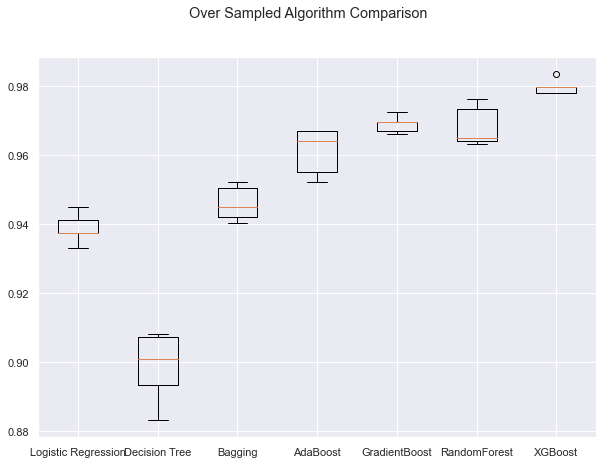

```python
fig = plt.figure(figsize=(10, 7))

fig.suptitle("Over Sampled Algorithm Comparison")
ax = fig.add_subplot(111)

plt.boxplot(over_results)
ax.set_xticklabels(names)

plt.show()
```

## Undersampled Data

```python
rus = RandomUnderSampler(random_state=1)
X_train_under, y_train_under = rus.fit_resample(X_train, y_train)
X_val_under, y_val_under = rus.fit_resample(X_val, y_val)
```

```python
print(f"Training\n")
print(f"Before Undersampling, counts of label 'Yes': {sum(y_train == 1)}")
print(f"Before Undersampling, counts of label 'No': {sum(y_train == 0)}")

print(f"After Oversampling, counts of label 'Yes': {sum(y_train_under == 1)}")
print(f"After Oversampling, counts of label 'No': {sum(y_train_under == 0)}")

print(f"After Oversampling, the shape of X_train_over: {X_train_under.shape}")
print(f"After Oversampling, the shape of y_train_over: {y_train_under.shape}")

print("\nValidation\n")
print(f"Before Undersampling, counts of label 'Yes': {sum(y_val == 1)}")
print(f"Before Undersampling, counts of label 'No': {sum(y_val == 0)}")

print(f"After Oversampling, counts of label 'Yes': {sum(y_val_under == 1)}")
print(f"After Oversampling, counts of label 'No': {sum(y_val_under == 0)}")

print(f"After Oversampling, the shape of X_train_over: {X_val_under.shape}")
print(f"After Oversampling, the shape of y_train_over: {y_val_under.shape}")
```

```
Training

Before Undersampling, counts of label 'Yes': 5439
Before Undersampling, counts of label 'No': 1041
After Oversampling, counts of label 'Yes': 1041
After Oversampling, counts of label 'No': 1041
After Oversampling, the shape of X_train_over: (2082, 32)
After Oversampling, the shape of y_train_over: (2082,)

Validation

Before Undersampling, counts of label 'Yes': 1360
Before Undersampling, counts of label 'No': 261
After Oversampling, counts of label 'Yes': 261
After Oversampling, counts of label 'No': 261
After Oversampling, the shape of X_train_over: (522, 32)
After Oversampling, the shape of y_train_over: (522,)
```

```python
under_results = []
names = []

# mean cross validaton score
print(f"\nUnder-Sampling Performance:\n")

for name, model in models:
    scoring = "recall"
    kfold = StratifiedKFold(n_splits=5, shuffle=True, random_state=1)
    cv_result = cross_val_score(
        estimator=model, X=X_train_under, y=y_train_under, scoring=scoring, cv=kfold
    )

    under_results.append(cv_result)
    names.append(name)
    print(f"{name}: {cv_result.mean() * 100}")

print(f"\nPerformance:\n")

for name, model in models:
    model.fit(X_train_under, y_train_under)
    scores = model_performance_classification_sklearn(
        model, X_train_under, y_train_under
    )
    val_scores = model_performance_classification_sklearn(
        model, X_val_under, y_val_under
    )
    print(f"{name}\n")
    print(f"Training Performace:")
    print(f"{scores}\n")

    print(f"Validation Performance:")
    print(f"{val_scores}\n")

    scorecard.append(("under_" + name, scores, val_scores))
```

```
Under-Sampling Performance:

Logistic Regression: 84.82011409642988
Decision Tree: 84.72534044902466
Bagging: 89.72304011777695
AdaBoost: 93.08198380566802
GradientBoost: 93.56275303643724
RandomForest: 92.02567169672433
XGBoost: 94.71567905778431

Performance:

Logistic Regression

Training Performace:
   Accuracy  Recall  Precision    F1
0     0.862   0.858      0.865 0.862

Validation Performance:
   Accuracy  Recall  Precision    F1
0     0.870   0.858      0.878 0.868

Decision Tree

Training Performace:
   Accuracy  Recall  Precision    F1
0     0.899   0.871      0.923 0.896

Validation Performance:
   Accuracy  Recall  Precision    F1
0     0.872   0.835      0.901 0.867

Bagging

Training Performace:
   Accuracy  Recall  Precision    F1
0     0.993   0.988      0.998 0.993

Validation Performance:
   Accuracy  Recall  Precision    F1
```

[output cut: 26 more lines]

```
0     1.000   1.000      1.000 1.000

Validation Performance:
   Accuracy  Recall  Precision    F1
0     0.933   0.939      0.928 0.933

XGBoost

Training Performace:
   Accuracy  Recall  Precision    F1
0     1.000   1.000      1.000 1.000

Validation Performance:
   Accuracy  Recall  Precision    F1
0     0.958   0.962      0.954 0.958
```

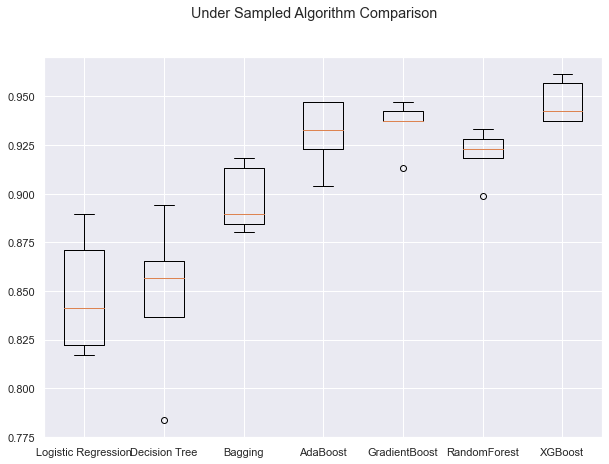

```python
fig = plt.figure(figsize=(10, 7))

fig.suptitle("Under Sampled Algorithm Comparison")
ax = fig.add_subplot(111)

plt.boxplot(under_results)
ax.set_xticklabels(names)

plt.show()
```

## Prime Model Selection (Top 3)

```python
for name, train_score, val_score in scorecard:
    print(f"{name}:\nTraining:\n{train_score}\nValidation:\n{val_score}\n")
```

```
Logistic Regression:
Training:
   Accuracy  Recall  Precision    F1
0     0.898   0.967      0.916 0.941
Validation:
   Accuracy  Recall  Precision    F1
0     0.901   0.973      0.915 0.943

Decision Tree:
Training:
   Accuracy  Recall  Precision    F1
0     0.929   0.985      0.935 0.959
Validation:
   Accuracy  Recall  Precision    F1
0     0.918   0.985      0.923 0.953

Bagging:
Training:
   Accuracy  Recall  Precision    F1
0     0.996   0.997      0.999 0.998
Validation:
   Accuracy  Recall  Precision    F1
0     0.951   0.979      0.962 0.971

AdaBoost:
Training:
   Accuracy  Recall  Precision    F1
0     0.964   0.983      0.974 0.979
Validation:
   Accuracy  Recall  Precision    F1
0     0.955   0.980      0.967 0.973

GradientBoost:
Training:
   Accuracy  Recall  Precision    F1
0     0.976   0.992      0.980 0.986
Validation:
   Accuracy  Recall  Precision    F1
0     0.966   0.992      0.968 0.980

```

[output cut: 112 more lines]

```
under_RandomForest:
Training:
   Accuracy  Recall  Precision    F1
0     1.000   1.000      1.000 1.000
Validation:
   Accuracy  Recall  Precision    F1
0     0.933   0.939      0.928 0.933

under_XGBoost:
Training:
   Accuracy  Recall  Precision    F1
0     1.000   1.000      1.000 1.000
Validation:
   Accuracy  Recall  Precision    F1
0     0.958   0.962      0.954 0.958
```

## Note

### HyperParameter Model 1 GradientBoost using RandomSearch on Overfit data

```python
%%time

model1 = GradientBoostingClassifier(random_state=1)

# Parameter grid to pass in RandomizedSearchCV
param_grid={
    "n_estimators": [100, 150, 200, 250],
    "subsample": [0.8, 0.9, 1],
    "max_features": [0.7, 0.8, 0.9, 1]
}


# Type of scoring used to compare parameter combinations
scorer = metrics.make_scorer(metrics.recall_score)

#Calling RandomizedSearchCV
gb_tuned2 = RandomizedSearchCV(estimator=model1, param_distributions=param_grid, n_iter=50, scoring=scorer, cv=5, random_state=1, n_jobs = -1)

gb_tuned2.fit(X_train_over, y_train_over)

print(f"Best parameters are {gb_tuned2.best_params_} with CV score={gb_tuned2.best_score_}:")
```

```
Best parameters are {'subsample': 0.9, 'n_estimators': 250, 'max_features': 0.8} with CV score=0.9819819118999945:
CPU times: user 4.97 s, sys: 532 ms, total: 5.5 s
Wall time: 1min
```

```python
gb_tuned2 = GradientBoostingClassifier(
    random_state=1, n_estimators=250, subsample=0.9, max_features=0.8
)
gb_tuned2.fit(X_train_over, y_train_over)
```

```
GradientBoostingClassifier(max_features=0.8, n_estimators=250, random_state=1,
                           subsample=0.9)
```

```
Training Performance:
   Accuracy  Recall  Precision    F1
0     0.991   0.990      0.992 0.991
```

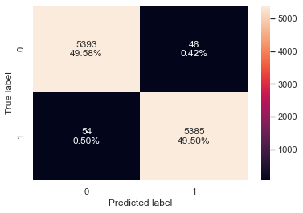

```python
gb_random_train = model_performance_classification_sklearn(
    gb_tuned2, X_train_over, y_train_over
)
print("Training Performance:")
print(gb_random_train)

print("*************************************")


# creating confusion matrix
confusion_matrix_sklearn(gb_tuned2, X_train_over, y_train_over)
```

```
Validation Performance:
   Accuracy  Recall  Precision    F1
0     0.977   0.982      0.972 0.977
```

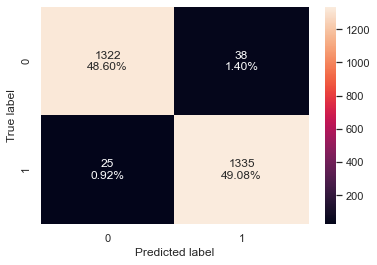

```python
gb_random_val = model_performance_classification_sklearn(
    gb_tuned2, X_val_over, y_val_over
)
print("Validation Performance:")
print(gb_random_val)

print("*************************************")


# creating confusion matrix
confusion_matrix_sklearn(gb_tuned2, X_val_over, y_val_over)
```

### HyperParameter Model 2, Random Forest using RandomSearch on Regular data

```python
%%time

model2 = RandomForestClassifier(random_state=1)

# Parameter grid to pass in RandomizedSearchCV
param_grid={"n_estimators": [150, 200, 250],
              "min_samples_leaf": np.arange(5,10),
              "max_features": np.arange(0.2, 0.7, 0.1),
              "max_samples": np.arange(0.3, 0.7, 0.1),
             }

# Type of scoring used to compare parameter combinations
scorer = metrics.make_scorer(metrics.recall_score)

#Calling RandomizedSearchCV
rf_tuned2 = RandomizedSearchCV(estimator=model2, param_distributions=param_grid, n_iter=50, scoring=scorer, cv=5, random_state=1, n_jobs = -1)

rf_tuned2.fit(X_train, y_train)

print(f"Best parameters are {rf_tuned2.best_params_} with CV score={rf_tuned2.best_score_}:")
```

```
Best parameters are {'n_estimators': 200, 'min_samples_leaf': 5, 'max_samples': 0.4, 'max_features': 0.2} with CV score=0.9862100221873478:
CPU times: user 1.67 s, sys: 212 ms, total: 1.88 s
Wall time: 33 s
```

```python
rf_tuned2 = RandomForestClassifier(
    random_state=1,
    n_estimators=200,
    min_samples_leaf=5,
    max_features=0.2,
    max_samples=0.4,
)
rf_tuned2.fit(X_train, y_train)
```

```
RandomForestClassifier(max_features=0.2, max_samples=0.4, min_samples_leaf=5,
                       n_estimators=200, random_state=1)
```

```
Training Performance:
   Accuracy  Recall  Precision    F1
0     0.959   0.992      0.960 0.976
```

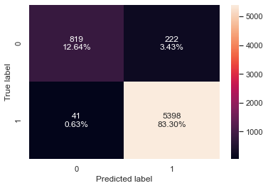

```python
rf_random_train = model_performance_classification_sklearn(rf_tuned2, X_train, y_train)
print("Training Performance:")
print(rf_random_train)

print("*************************************")


# creating confusion matrix
confusion_matrix_sklearn(rf_tuned2, X_train, y_train)
```

```
validation Performance:
   Accuracy  Recall  Precision    F1
0     0.936   0.987      0.940 0.963
```

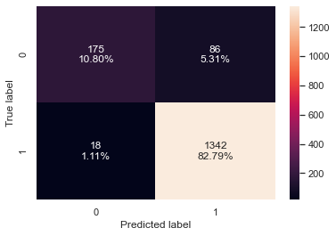

```python
rf_random_val = model_performance_classification_sklearn(rf_tuned2, X_val, y_val)
print("validation Performance:")
print(rf_random_val)

print("*************************************")


# creating confusion matrix
confusion_matrix_sklearn(rf_tuned2, X_val, y_val)
```

### HyperParameter Model 3, XGBoost using RandomSearch on Regular Data

```python
%%time

model3 = XGBClassifier(random_state=1,eval_metric='logloss')

# Parameter grid to pass in RandomizedSearchCV
param_grid={'n_estimators':np.arange(50,150,50),
            'scale_pos_weight':[2,5,10],
            'learning_rate':[0.01,0.1,0.2,0.05],
            'gamma':[0,1,3,5],
            'subsample':[0.8,0.9,1],
            'max_depth':np.arange(1,5,1),
            'reg_lambda':[5,10]}

# Type of scoring used to compare parameter combinations
scorer = metrics.make_scorer(metrics.recall_score)

#Calling RandomizedSearchCV
xgb_tuned2 = RandomizedSearchCV(estimator=model3, param_distributions=param_grid, n_iter=50, scoring=scorer, cv=5, random_state=1, n_jobs = -1)

#Fitting parameters in RandomizedSearchCV
xgb_tuned2.fit(X_train,y_train)

print(f"Best parameters are {xgb_tuned2.best_params_} with CV score={xgb_tuned2.best_score_}:")
```

```
Best parameters are {'subsample': 0.8, 'scale_pos_weight': 2, 'reg_lambda': 10, 'n_estimators': 100, 'max_depth': 1, 'learning_rate': 0.01, 'gamma': 5} with CV score=1.0:
CPU times: user 2 s, sys: 202 ms, total: 2.21 s
Wall time: 13.1 s
```

```python
xgb_tuned2 = XGBClassifier(
    random_state=1,
    n_estimators=100,
    scale_pos_weight=2,
    gamma=5,
    subsample=0.8,
    learning_rate=0.01,
    eval_metric="logloss",
    max_depth=1,
    reg_lambda=10,
)
# Fit the model on training data
xgb_tuned2.fit(X_train, y_train)
```

```
XGBClassifier(base_score=0.5, booster='gbtree', colsample_bylevel=1,
              colsample_bynode=1, colsample_bytree=1, eval_metric='logloss',
              gamma=5, gpu_id=-1, importance_type='gain',
              interaction_constraints='', learning_rate=0.01, max_delta_step=0,
              max_depth=1, min_child_weight=1, missing=nan,
              monotone_constraints='()', n_estimators=100, n_jobs=0,
              num_parallel_tree=1, random_state=1, reg_alpha=0, reg_lambda=10,
              scale_pos_weight=2, subsample=0.8, tree_method='exact',
              validate_parameters=1, verbosity=None)
```

```
Training Performance:
   Accuracy  Recall  Precision    F1
0     0.839   1.000      0.839 0.913
```

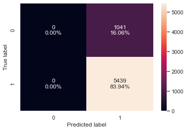

```python
# Calculating different metrics on train set
xgboost_random_train = model_performance_classification_sklearn(
    xgb_tuned2, X_train, y_train
)
print("Training Performance:")
print(xgboost_random_train)

print("*************************************")


# creating confusion matrix
confusion_matrix_sklearn(xgb_tuned2, X_train, y_train)
```

```
Validation performance:
   Accuracy  Recall  Precision    F1
0     0.839   1.000      0.839 0.912
```

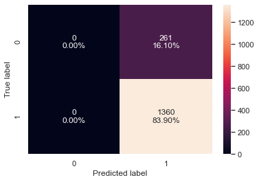

```python
# Calculating different metrics on train set
xgboost_random_val = model_performance_classification_sklearn(xgb_tuned2, X_val, y_val)
print("Validation performance:")
print(xgboost_random_val)

print("*************************************")


# creating confusion matrix
confusion_matrix_sklearn(xgb_tuned2, X_val, y_val)
```

## Hyperparameter model performace

```python
models_train_comp_df = pd.concat(
    [gb_random_train.T, rf_random_train.T, xgboost_random_train.T,], axis=1
)
models_train_comp_df.columns = [
    "GradientBoost with Random Search",
    "Random Forest with Random Search",
    "XGBoost with Random Search",
]

print("Training Performance Comparison")
models_train_comp_df
```

```
Training Performance Comparison
```

|  | GradientBoost with Random Search | Random Forest with Random Search | XGBoost with Random Search |
| --- | --- | --- | --- |
| Accuracy | 0.991 | 0.959 | 0.839 |
| Recall | 0.990 | 0.992 | 1.000 |
| Precision | 0.992 | 0.960 | 0.839 |
| F1 | 0.991 | 0.976 | 0.913 |

```python
models_val_comp_df = pd.concat(
    [gb_random_val.T, rf_random_val.T, xgboost_random_val.T,], axis=1
)
models_val_comp_df.columns = [
    "GradientBoost with Random Search",
    "Random Forest with Random Search",
    "XGBoost with Random Search",
]

print("Validaton Performance Comparison")
models_val_comp_df
```

```
Validaton Performance Comparison
```

|  | GradientBoost with Random Search | Random Forest with Random Search | XGBoost with Random Search |
| --- | --- | --- | --- |
| Accuracy | 0.977 | 0.936 | 0.839 |
| Recall | 0.982 | 0.987 | 1.000 |
| Precision | 0.972 | 0.940 | 0.839 |
| F1 | 0.977 | 0.963 | 0.912 |

# Pipeline to use the test data using only the best performing model

```python
pipe = make_pipeline(GradientBoostingClassifier(random_state=1))
```

```python
pipe.steps
```

[('gradientboostingclassifier', GradientBoostingClassifier(random_state=1))]

```python
pipe.fit(X_train_over, y_train_over)
```

```
Pipeline(steps=[('gradientboostingclassifier',
                 GradientBoostingClassifier(random_state=1))])
```

```python
pipe.score(X_train_over, y_train_over)
```

```
0.9789483360911932
```

```python
pipe.score(X_test, y_test)
```

```
0.9639684106614018
```